# FooR

J. Antonio García, jose.ramirez@cimat.mx

2018-01-12

```r
library(FooR)
library(xtable)
library(pander)
library(dplyr)
```

```r
library(ggplot2)
library(readr)
```

This vignette two process: - Cleaning - Two different visualizations (over time - like [Doctor Who](https://en.wikipedia.org/wiki/Doctor_Who) would see it - and country)

About the NOAA earthquake data. the data come can be obtained from [NOAA Significant Earthquake Database](https://www.ngdc.noaa.gov/nndc/struts/form?t=101650&s=1&d=1).

## Package content

There are ten functions within the package:

- `fecha()`
- `eq_clean_data()`
- `eq_location_clean()`
- `theme_timeline()`
- `GeomTimeline()`
- `GeomTimelineLabel()`
- `theme_timeline()`
- `geom_timeline()`
- `geom_timeline_label()`
- `eq_map()`

But only the following functions are exported:

## Data

| I_D | FLAG_TSUNAMI | YEAR | MONTH | DAY | HOUR | MINUTE | SECOND |
| --- | --- | --- | --- | --- | --- | --- | --- |
| 1 | NA | -2150 | NA | NA | NA | NA |  |
| 3 | NA | -2000 | NA | NA | NA | NA | NA |

| FOCAL_DEPTH | EQ_PRIMARY | EQ_MAG_MW | EQ_MAG_MS | EQ_MAG_MB | EQ_MAG_ML |
| --- | --- | --- | --- | --- | --- |
| NA | 7.3 | NA | NA | NA | NA |

[output not shown]

| EQ_MAG_MFA | EQ_MAG_UNK | INTENSITY | COUNTRY | STATE |
| --- | --- | --- | --- | --- |
| NA | 7.3 | NA | JORDAN | NA |
| NA | NA | 10 | TURKMENISTAN | NA |

| LOCATION_NAME |
| --- |
| JORDAN: BAB-A-DARAA,AL-KARAK |
| TURKMENISTAN: W |

## Data cleaning

It is evident that the data set has numerous columns with null or missing values, although a future and interesting work for this package would be to apply data imputation techniques to the dataset . For the above you can use the function *eq_clean_data()* and *eq_location_clean*

```r
NOAA <- as.data.frame(NOAA)
NOAA <- eq_clean_data(NOAA)
NOAA <- eq_location_clean(NOAA)
```

## Visualization of earthquakes by time and place :

1. [Doctor-Who](https://en.wikipedia.org/wiki/Doctor_Who)‘s view ( or style1), *all the time* and *all the countries* at once. You can visualize earthquakes in all dataset’s time variable *YEAR* without filter by the columns *COUNTRY* and *YEAR* and using the package *ggplot* and the recently implemented *geom_*, *geom_timeline* and *geom_timeline_label*. (you must pay attention with the column so that the visualization is of a suitable size and not empty, as in every ggplot´s function, one must have congruent with the variables’ name of the dataset and the parameters of *ggplot2::aes* function.)[^1]

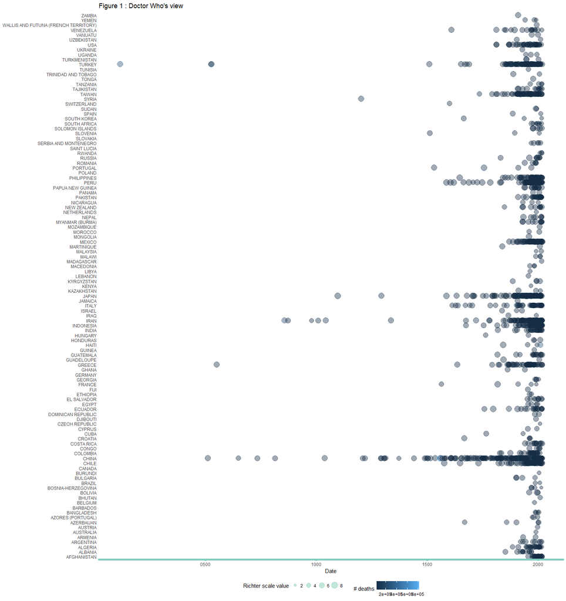

```r
NOAA %>%
filter( DEATHS>0) %>%
     ggplot(aes(x = Date,
                y = COUNTRY,
                color = DEATHS,
                size = as.numeric(EQ_PRIMARY)
     )) +
     geom_timeline() +
     #geom_timeline_label(aes(label = LOCATION_NAME)) +
     theme_timeline() +
     labs(size = "Richter scale value", color = "# deaths",
          title = "Figure 1 : Doctor Who's view")
```

2. No-Doctor-Who’s (style2), not all the time neither all the countries at once. You can visualize earthquakes in a single country after filter by the column *COUNTRY* or many others, (you must pay attention with the columns of *YEAR* and *DEATHS* so that the visualization is of a suitable size and not empty, as in every ggplot´s function, one must have congruent with the variables’ name of the dataset and the parameters of *ggplot2::aes* function.)

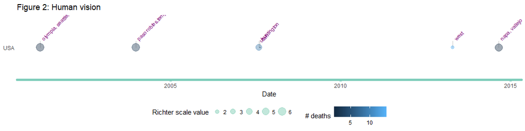

```r
NOAA %>%
filter(COUNTRY %in% c("USA"), 2020 > YEAR,  YEAR > 2000, DEATHS>0) %>%
     ggplot(aes(x = Date,
                y = COUNTRY,
                color = DEATHS,
                size = as.numeric(EQ_PRIMARY)
     )) +
     geom_timeline() +
     geom_timeline_label(aes(label = LOCATION_NAME)) +
     theme_timeline() +
     labs(size = "Richter scale value", color = "# deaths",
     title = "Figure 2: Human vision")
```

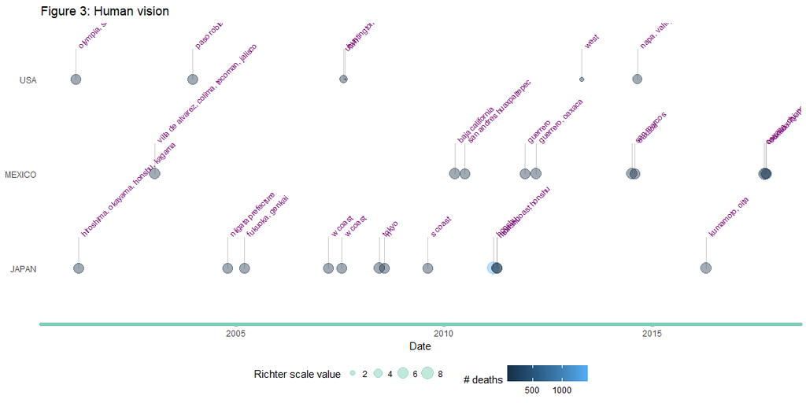

```r
NOAA %>%
filter(COUNTRY %in% c("USA", "MEXICO", "JAPAN"), 2020 > YEAR,  YEAR > 2000, DEATHS>0) %>%
     ggplot(aes(x = Date,
                y = COUNTRY,
                color = DEATHS,
                size = as.numeric(EQ_PRIMARY)
     )) +
     geom_timeline() +
     geom_timeline_label(aes(label = LOCATION_NAME)) +
     theme_timeline() +
     labs(size = "Richter scale value", color = "# deaths",
     title = "Figure 3: Human vision")
```

# Visualize earthquakes on a pretty map

Using the *leaflet* package it is very easy to make beautiful interactive maps using the function *eq_map()*.There are two options to use this function one without using the function *eq_create_label()* from where we get the following map:

```r
NOAA %>%
   dplyr::filter(COUNTRY == "MEXICO" & lubridate::year(Date) >= 2000) %>%
  eq_map(annot_col = "DATE")
```

[interactive chart not shown]

And the other one using it

```r
NOAA %>%
 dplyr::filter(COUNTRY == "MEXICO" & lubridate::year(Date) >= 2000) %>%
  dplyr::mutate(popup_text = eq_create_label(.)) %>%
  eq_map(annot_col = "popup_text")
```

[interactive chart not shown]

[^1]: Thanks to my [brother](https://www.facebook.com/lucaridavidmisticmaster) and my friend [Claudia](https://www.facebook.com/Ayla.occord?pnref=friends.search) for the idea about figure 1.